# ESE5023_Assignments_12132661

## ZHANG Yixuan (张逸轩)'s TA report for assignment01

## SID: 12132661

## Github: https://github.com/YixuanZhang1005/ESE5023_Assignments_12132661

## Responsible TA: HUANG Hao

## Grade: 95

In the very beginning, I would like to express my appreciation of your clear report and simple code. I am sorry your assignment could not gain more points, but I give you a star for your Github.

## Flowchart in PS1_1.py (10/10)

Well done!

```python
def Print_values(a, b, c):
    if a > b:
        if b > c:
            print(a, b, c)
        elif a > c:
            print(a, c, b)
        else:
            print(c, a, b)
    elif b > c:
            print('null')
    else:
            print(c, b, a)
```

```python
Print_values(4, 5, 6)
```

```
6 5 4
```

## Matrix multiplication in PS1_2.py (15/15)

Good. But I suggest you not to use `np.zeros()` and `np.shape()`. Because if numpy is available in 2.2, you can directly multiply M1 by M2 by functions like `numpy.matmul`.

```python
import numpy as np
M1 = np.mat(np.random.randint(51, size=(5,10)))
M2 = np.mat(np.random.randint(51, size=(10,5)))
print(M1, '\n', M2)
```

```
[[36 27 12 47 37  6 28 12 42 27]
 [36 17 39 35  6 22 49 38 35 22]
 [41 42  9 37  4 10 34 46 40 10]
 [28 42 41 48 23 11 45  4 35 34]
 [ 7 20 22 17 29 36 25  0 48 23]]
 [[41 40 38 11 29]
 [49 32 13 35 44]
 [42 27 11 22 19]
 [49 30 12  6 26]
 [ 4 36 49  5 26]
 [27 29 37  6 45]
 [38  2 33  7 40]
 [23 19 34  3 20]
 [36 39 25 12 20]
 [ 3 43  9 28 46]]
```

```python
def Matrix_multip(M1, M2):
    new_matrix = np.mat(np.zeros([M1.shape[0], M1.shape[0]], int))
    for i in range(M1.shape[0]):
        for j in range(M2.shape[1]):
            tmp = 0
            for k in range(M1.shape[1]):
                tmp += M1[i,k] * M2[k,j]
                new_matrix[i,j] = tmp
    return new_matrix
```

```python
print(Matrix_multip(M1, M2))
```

```
[[ 8849  8627  7075  3600  8356]
 [10342  8072  7528  3714  9021]
 [10036  7703  6989  3557  8264]
 [10833  9151  6973  4848  9924]
 [ 6859  7023  5957  3119  7335]]
```

## Pascal triangle in PS1_3.py (20/20)

Well done! Some students calculate $\frac{n!}{k!(n-k)!}$ for the number in row n and term k (https://www.mathsisfun.com/pascals-triangle.html), but you provided a method that was based on the basic feature of Pascal triangle.

```python
def triangles(k):
    if k <= 0:
        print("please input number > 0")
    else:
        k = k-1
        L = []
        l = [1]
        L.append(l)
        index = 0
        while index < k:
            index += 1
            l.append(0)
            l = [l[i-1] + l[i] for i in range(0,len(l))]
            L.append(l)
        print(L[k])
```

```python
triangles(100)
```

```
[1, 99, 4851, 156849, 3764376, 71523144, 1120529256, 14887031544, 171200862756, 1731030945644, 15579278510796, 126050526132804, 924370524973896, 6186171974825304, 38000770702498296, 215337700647490344, 1130522928399324306, 5519611944537877494, 25144898858450330806, 107196674080761936594, 42878669632…
```

## Add or double in PS1_4.py (20/20)

Well done! I enjoy your simple code and also your clear report which even include each step.

```python
def Least_moves(x):
    step = 0
    while x != 1:
        if x % 2 == 0:
            x /= 2
        else:
            x -= 1
        step += 1
    print(step)
```

```python
Least_moves(100)
```

```
8
```

## Dynamic programming in PS1_5.1.py and PS1_5.2.py (30/35)

You forgot to define num in the very beginning. Without this little mistake, it is possible for your assigment to gain more than 100 points. However, this little bug made the code unable to run. So, 5 points were deducted. Whatever, I enjoy your figure, especially the annotation that no student has done before. Thanks for writing code seriously.

```python
def Find_expression(x):
    sign = ['+', '-', ' ']
    sign_line = ''
    last_sign = ['+', '-', ' ']
    all_sign = []
    answer = []
    # find all conbinations of sign
    for i in range(7):
        new_sign = []
        for j in range(3):
            for k in range(len(last_sign)):
                sign_line = last_sign[k] + sign[j]
                new_sign.append(sign_line)
        last_sign = new_sign
        all_sign = new_sign

    for i in range(len(new_sign)):
        expre = '1'
        for j in range(8):
            if new_sign[i][j] == ' ':
                expre = expre + num[j+1]
            else:
                expre = expre + new_sign[i][j] + num[j+1]
        if eval(expre) == x:
            expre = expre + '=' + str(x)
            print(expre)
            answer.append(expre)
```

```python
Find_expression(50)
```

```
---------------------------------------------------------------------------
NameError                                 Traceback (most recent call last)
/var/folders/qy/ngsg7cz10ys7fn_5n46kknmr0000gn/T/ipykernel_3158/3385124129.py in <module>
----> 1 Find_expression(50)

/var/folders/qy/ngsg7cz10ys7fn_5n46kknmr0000gn/T/ipykernel_3158/59442805.py in Find_expression(x)
     21                 expre = expre + num[j+1]
     22             else:
---> 23                 expre = expre + new_sign[i][j] + num[j+1]
     24         if eval(expre) == x:
     25             expre = expre + '=' + str(x)

NameError: name 'num' is not defined
```

```python
##modified by HUANG
def Find_expression(x):
    sign = ['+', '-', ' ']
    sign_line = ''
    last_sign = ['+', '-', ' ']
    all_sign = []
    answer = []
    num = ['1','2','3','4','5','6','7','8','9']
    # find all conbinations of sign
    for i in range(7):
        new_sign = []
        for j in range(3):
            for k in range(len(last_sign)):
                sign_line = last_sign[k] + sign[j]
                new_sign.append(sign_line)
        last_sign = new_sign
        all_sign = new_sign

    for i in range(len(new_sign)):
        expre = '1'
        for j in range(8):
            if new_sign[i][j] == ' ':
                expre = expre + num[j+1]
            else:
                expre = expre + new_sign[i][j] + num[j+1]
        if eval(expre) == x:
            expre = expre + '=' + str(x)
            print(expre)
            answer.append(expre)
```

```python
Find_expression(50)
```

```
1+2+34-5-6+7+8+9=50
1-2-3+4+56-7-8+9=50
1-2+3-45+6+78+9=50
1-23-4-5-6+78+9=50
12+3+4-56+78+9=50
1-2+34+5+6+7+8-9=50
1+2+3-4+56-7+8-9=50
12-3+45+6+7-8-9=50
1+2-3+4+56+7-8-9=50
12-3-4-5+67-8-9=50
1-23+4+5-6+78-9=50
1-2-3-4-5-6+78-9=50
1+2+34-56+78-9=50
1-2-34-5-6+7+89=50
1+2+3+4-56+7+89=50
1+2-34+5-6-7+89=50
1-2+34-5-67+89=50
```

```python
##Also modified by adding what is num.
import matplotlib.pyplot as plt

import numpy as np
def Find_expression(x):
    sign = ['+', '-', ' ']
    sign_line = ''
    last_sign = ['+', '-', ' ']
    all_sign = []
    answer = []
    num = ['1','2','3','4','5','6','7','8','9']
    for i in range(7):
        new_sign = []
        for j in range(3):
            for k in range(len(last_sign)):
                sign_line = last_sign[k] + sign[j]
                new_sign.append(sign_line)
        last_sign = new_sign
        all_sign = new_sign

    for i in range(len(new_sign)):
        expre = '1'
        for j in range(8):
            if new_sign[i][j] == ' ':
                expre = expre + num[j+1]
            else:
                expre = expre + new_sign[i][j] + num[j+1]
        if eval(expre) == x:
            expre = expre + '=' + str(x)
            # print(expre)
            answer.append(expre)
    return len(answer)
```

```python
Total_solutions = []
for i in range(0,101):
    Total_solutions.append(Find_expression(i))
print(Total_solutions)
```

```
[11, 26, 11, 18, 8, 21, 12, 17, 8, 22, 12, 21, 11, 16, 15, 20, 8, 17, 11, 20, 15, 16, 11, 23, 18, 13, 14, 21, 15, 19, 17, 14, 19, 19, 7, 14, 19, 19, 17, 18, 16, 17, 18, 10, 15, 26, 18, 15, 16, 12, 17, 19, 9, 17, 21, 16, 13, 14, 16, 17, 17, 11, 13, 22, 14, 13, 15, 15, 15, 17, 7, 14, 17, 15, 12, 13, 1…
```

```
[1, 45]
```

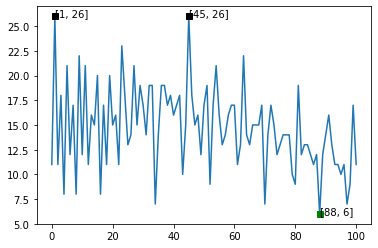

```python
max_index = np.argwhere(Total_solutions == np.amax(Total_solutions))
min_index = np.argwhere(Total_solutions == np.amin(Total_solutions))
max_index = max_index.flatten().tolist()
min_index = min_index.flatten().tolist()
print(max_index)
plt.plot(Total_solutions)
for i in range(len(max_index)):
    plt.plot(max_index[i],Total_solutions[max_index[i]],'ks')
    show_max='['+str(max_index[i])+', '+str(Total_solutions[max_index[i]])+']'
    plt.annotate(show_max,xytext=(max_index[i],Total_solutions[max_index[i]]),xy=(max_index[i],Total_solutions[max_index[i]]))
for i in range(len(min_index)):
    plt.plot(min_index[i],Total_solutions[min_index[i]],'gs')
    show_min='['+str(min_index[i])+', '+str(Total_solutions[min_index[i]])+']'
    plt.annotate(show_min,xytext=(min_index[i],Total_solutions[min_index[i]]),xy=(min_index[i],Total_solutions[min_index[i]]))
plt.show()
```